Introduction)

Background: Dermatitis is a skin condition where one may have overly dry and weak skin which can then be prone to infections, redness, and other ailments. Dermatitis is known to go away with age. 10% of children are diagnosed with dermatitis then grow out of it, while only 1% of adults observe dermatitis (Golonzhka O, Leid M, Indra G, Indra AK. Expression of COUP-TF-interacting protein 2 (CTIP2) in mouse skin during development and in adulthood. Gene Expr Patterns. 2007 Aug;7(7):754-60. doi: 10.1016/j.modgep.2007.06.002. Epub 2007 Jun 13. PMID: 17631058; PMCID: PMC2063996.https://www.ncbi.nlm.nih.gov/pmc/articles/PMC8383845/). So then the protein linked to dermatitis by being a component in building up the skin barrier (this linkage has currently only been tested in mice studies but the protein itself is found in both humans and mice). CTIP2 is found to actual be expressed fewer in adult healthy mice then when developing embryos based on research findings(Ganguli-Indra G, Liang X, Hyter S, Leid M, Hanifin J, Indra AK. Expression of COUP-TF-interacting protein 2 (CTIP2) in human atopic dermatitis and allergic contact dermatitis skin. Exp Dermatol. 2009 Nov;18(11):994-6. doi: 10.1111/j.1600-0625.2009.00876.x. Epub 2009 Mar 29. PMID: 19366371; PMCID: PMC2783464. https://pubmed.ncbi.nlm.nih.gov/19366371/). CTIP2 is also sometimes called as BC11B, so some data may also be named BC11B.

Scientific question: So then how closely similar are the CTIP2 protein in mice are to humans (in terms of DNA sequence and protein structure), in order to make an assumption that CTIP2 is also linked to dermatitis in humans?

Scientific hypothesis: If the human and mouse CTIP2 protein are closely similar, then we can assume their protein structures and DNA sequences to be similar as well.

The first database I’ll be utilizing is the NCBI(Nucleotide database). I can find 2 different gene encoding for Ctip2, one for humans and mice. Then the method I’ll be using from method list 1 is Pairwise sequence alignment to analyze the different genes to see how similar they are. I’ll plot the results on a Sequence Logos.

Next I’ll USE swiss to find the different proteins PDB files and use Homology Modeling and Structural Bioinformatics to compare them in PyMol. I’ll plot the results with 3D protein.

The code: Loading in Packages)

```r
#Most of these packages you should already have pre-installed in your R-studio. If not you can  uncomment the line below to install said packages first and then you are able to load them in with the library function.

#install.packages("BiocManager")
#install.packages("Biostrings")
#install.packages("Seqnir")
#install.packages("DESeq2")
#install.packages('readr')
#install.packages("ggseqlogo")
#install.packages("vembedr)
#install.packages("NGLVieweR")


#When loading in the packages here through the library function the console may asked whether
#you want to "Update all/some/none"?
#You can just type n for none in the console:

library(BiocManager)
# BiocManager package allows for access to other bioinformatics packages within BiocManager. Able to access various statistical analysis's and genomic data. It helps install other package aa well like MSA. https://cran.r-project.org/web/packages/BiocManager/vignettes/BiocManager.html

library(Biostrings)
```

```r
# ^^ Allows for use of many sequence allighmnet functions, like nucleotideSubsitutionMatrix(). I used this packae with my methos 1 of pairwise allighment method. https://bioconductor.org/packages/release/bioc/html/Biostrings.html

library(readr)
#install readr if not done already, readr helps provide statistical methods. It's a way to quicly read in rectanglar data and other files like CSV and TSV files.Able to parse many datatypes.
#https://readr.tidyverse.org/

library(vembedr)
# The vembedr package lets you embed video into your HTML pages in R with the embed_url() function. Not much else to say. I uses this to show my comparison movie of the two protein structures of CTIP2.
#https://cran.r-project.org/web/packages/vembedr/index.html

require(ggplot2)
require(ggseqlogo)
# ^^ These two packages help with the sequence logos method. Helping take in multiple sequence alignments and then spitting out the derived seq logos from them. Can either take in pariwise or multiple sequence alignments but they must be in a character vector.
# https://omarwagih.github.io/ggseqlogo/

library(NGLVieweR)
# NGLVieweR can be used to visualize and interact with Protein Data Bank (PDB) and structural files in R. It includes a set of API functions to manipulate the viewer after creation in Shiny. Able to apply filters like sticks and mesh on the 3d visualization.
#https://cran.r-project.org/web/packages/NGLVieweR/index.html
```

Performing Bioinformatics Analysis)

Reading in the data:

```r
# Using the first dataset NCBI(Nucleotides) to find the human and mice genes of CTIP2 as fasta files and then reading them in. This is creating all global variables here which I access throughout my code at various points:
Human_CTIP2 <- readAAStringSet(file = "Human CTIP2.fasta") #BP length of 8525 #https://www.ncbi.nlm.nih.gov/nuccore/NM_001282237.2
Mice_CTIP2 <- readAAStringSet(file = "Mice CTIP2.fasta") #BP length of 2697 #https://www.ncbi.nlm.nih.gov/nuccore/AF186019.1
#^^ The code creates a single long string all in uppercase letters
```

Method 1 Pairwise sequence alignment:

```r
# The pairwise sequence alignment mehod will allign the 2 sequences give to the best match, then calcualting a score based on that new allignment with it adding to the score everythime there is a match or subtracting from everytime their isn't.



#source: https://a-little-book-of-r-for-bioinformatics.readthedocs.io/en/latest/src/chapter4.html
nucleotidematrix = nucleotideSubstitutionMatrix(match = 2, mismatch = -1, baseOnly = TRUE)
# This function just helps to create a nucleotide matirix to compare different nucleotide, which we'll use later when preforming pairwaise sequence allighment on the DNA of CTIP2 in both mice and humans down below.

# nucleotidematrix
# Uncomment the code above check to see if the nucleotide matrix is properly made and has ACTG.

globalAlignsequence1sequence2 = pairwiseAlignment(Human_CTIP2, Mice_CTIP2, substitutionMatrix = nucleotidematrix, gapOpening = -2, gapExtension = -8, scoreOnly = FALSE)
globalAlignsequence1sequence2
```

```
## Global PairwiseAlignmentsSingleSubject (1 of 1)
## pattern: AGCCATAGAGAGACCGAGAGCTCCCAGAGAACCC...AAAAATAAATTGGACATTTAACTTGATCTCCAAA
## subject: -G--------------------------------...----------------------------------
## score: -42444
```

```r
# This code just compares the sequences given. It takes in a singular long string as the sequence and also the the nucelotide  as a matrix in order to compare them. The it spits out best alignment pattern and a score.

#Make your own function
test_alignment_score = function(x){ #X is a local variable made in my function and can only be accessed within the function.

  if (x  > 0){ #This if statement helps check whether the score is positive or not.
    print("It's a positive score and a good alighment because the sequences are similar")
  }

  else{ #The else statement helps check whether the score is positive or not.
    print("It's a negative score and so a bad alighment because the sequences aren't similar")
  }

}
```

```r
test_alignment_score(-42444)
```

```
## [1] "It's a negative score and so a bad alighment because the sequences aren't similar"
```

```r
# Testing the aliment score we got from the pairwise Alignment function in the code chunk above. I input the score that was give to me for the aliment score of the CTIP2 comparison.
```

Method 2, Homolgy model and structural bioinformatics.

```r
# This method was comparing the structures of the proteins in PyMol. Making not of any observations for where their were differences or similarities.


embed_url("https://youtu.be/-wZdZdDbmi4")
```

[video not shown]

```r
# This code simply opens up the link to my movie comparing the protein structures of CTIP2 in both humans and mice
```

Plotting The Results)

Sequence logos data analysis https://omarwagih.github.io/ggseqlogo/#getting_started

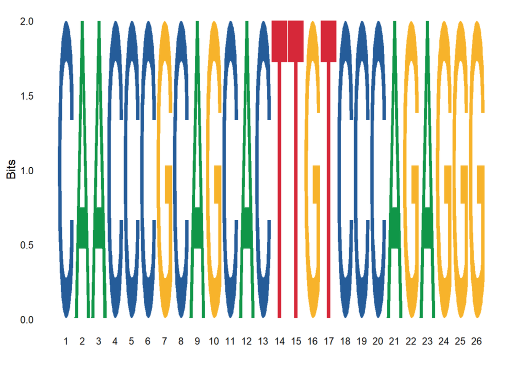

```r
#Sequence logo helps present the most fundamental information from a multiple alignment. With hight of the character correlating to conservation of that nucleotide in that alighment column and width of that character representing the abundance of that nucelotide in that alignment column


#Checks to see if the ggseqlogo() functions properly work using the sample data given in the package.
#ggseqlogo( seqs_dna$MA0001.1)
#ggseqlogo( seqs_aa$AKT1 )

#You can also pass in a list of sequences directly into the ggseqlogo() function to get a seq logo so long as the sequences are of the same length.
#multi = c(substring(Human_CTIP2,1025,1040), substring(Mice_CTIP2,1025,1040))
#ggseqlogo(multi)



logo_globalAlignsequence1sequence2 = as.character(globalAlignsequence1sequence2)
#^^ Converts a datatype into a character vector
trimlogo_globalAlignsequence1sequence2 = substring(logo_globalAlignsequence1sequence2,1000,1025)
#substring() is a built-in Bioconductor function. It takes in a character vector and helps trim it down to the specified parameters.

ggseqlogo(trimlogo_globalAlignsequence1sequence2)
```

```r
# Takes in a character to give you a sequence logo.
```

3D protein

```r
# https://github.com/nvelden/NGLVieweR#:~:text=NGLvieweR%20provides%20an%20R%20interface,in%20R%20and%20Shiny%20applications.
# Source: https://cran.r-project.org/web/packages/NGLVieweR/vignettes/NGLVieweR.html



NGLVieweR("BC11B_HUMAN.pdb") %>%
addRepresentation("cartoon")
```

[interactive chart not shown]

```r
# ^^ This code presents the 3D image of the protein as given by the PDB file. This once plots the protein of human CTIP2. Rmber CTIP2 is also sometimes referred to as BC11B.
NGLVieweR("BC11B_MOUSE.pdb") %>%
addRepresentation("cartoon")
```

[interactive chart not shown]

```r
# ^^ This one plots the  CTIP2 protein for mice.
```

Analyzing the Results)